# NanoString Collection of CosMx SMIDA custom module scripts

This repository contains R script that can be used in custom modules in the AtoMx SMIDA.

[output not shown]

## Instructions:

Download R script from NanoString [website](https://nanostring.com/) or [GitHub](https://github.com/Nanostring-Biostats/CosMxDACustomModules)

Instructions from [User Manual](https://university.nanostring.com/cosmx-smi-data-analysis-user-manual)

From the Pipeline Run panel, click the custom modules icon.

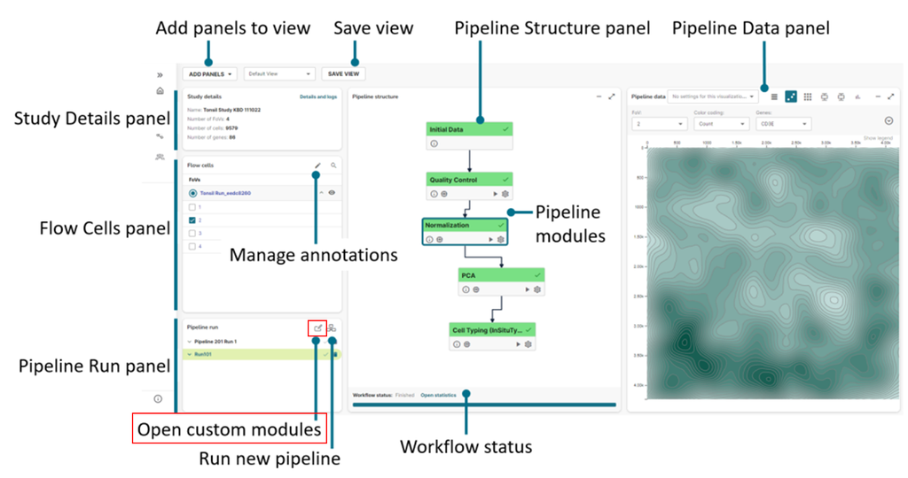

The Custom Modules window opens. Edit or delete existing custom modules with the pencil and trash icons, respectively.

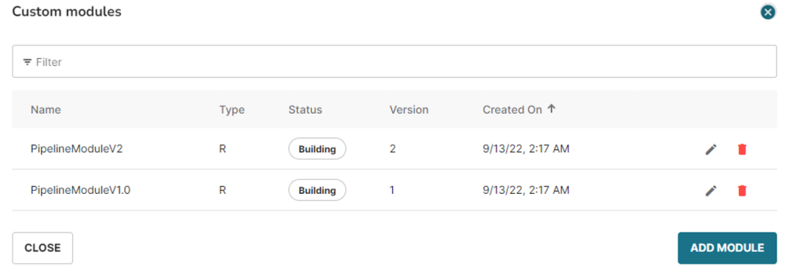

To add a new custom module to the pipeline, click Add Module. The Add New Module window opens. Enter information about the new module, including name (required), description, parameters, packages (click + to input package information), arguments (click + to input arguments), and/or entry point. Additionally, you can upload custom script files. Variables required and recommended parameters for individual scripts will be located in the CosMxDA[*ModuleName*]Setup.docx file in each folder.

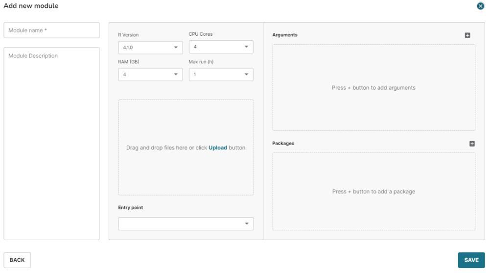

Click Save to exit and add the defined module to the Custom Modules list, or exit without saving by clicking the x in the top right.